# **Preferencias de los estudiantes UTEC al almorzar en la calle**

# **TEMA**

*Preferencias de los estudiantes UTEC al almorzar en la calle*

# **INTRODUCCIÓN**

## *Relevancia*

- Comer en la calle es algo muy común para muchos, es por eso que nuestro proyecto se basa en el análisis de los hábitos comestibles y alimenticios de los estudiantes al momento de comer en la calle e incluso al momento de pedir los alimentos de forma remota.

## *Objetivos del estudio*

- Objetivo general:

  Analizar y estudiar la información acerca del tipo de alimentación de los estudiantes, en cuanto a los métodos que usan para obtener los alimentos fuera de su hogar y sus preferencia acerca de la comida en la calle.
- Objetivo específico:
  - Estudiar las preferencias a la hora de ir a comer en la calle de los estudiantes UTEC.
  - Conocer la cantidad necesaria de tiempo que los individuos requieren para consumir sus alimentos.
  - Determinar las razones de los métodos de pago preferidos y la cantidad de dinero que gastan los estudiantes UTEC

## *Contexto*

Para comprender adecuadamente el tema propuesto sobre las preferencias de los estudiantes UTEC al almorzar en la calle, es importante tener en cuenta algunos conocimientos relevantes. Aquí hay algunos aspectos que se deben considerar:

- Hábitos alimenticios de los estudiantes universitarios: Los estudiantes universitarios a menudo tienen horarios ocupados y limitado tiempo para preparar comidas en casa. Por lo tanto, es común que busquen opciones de comida rápida y conveniente, como comer en la calle o pedir comida para llevar.
- Lugares de almuerzo: Nos referimos a restaurantes, cafeterías, comedores externos a lo que sería la preparación propia o familiar de la comida.

# **DATOS**

## Recolección de datos

Los datos se obtuvieron por medio de encuestas virtuales a través de Google Forms, ya que nos permite descargar toda la data recolectada directamente en formato ‘.csv’, listo para poder trabajar en Rstudio.

## Población, muestra y muestreo

*Población:* Todos los estudiantes de pre grado de la UTEC que estén cursando el semestre 2023-1.

*Muestra:* El tamaño de nuestra muestra es de 159 estudiantes, lo que sugiere que es una muestra representativa que nos permitirá trabajar en el estudio que queremos.

*Muestreo:* El muestreo fue por conveniencia, porque antes de que pidiéramos a los estudiantes que llenaran nuestra encuesta, le preguntábamos `"¿Comen en la calle?"` para que su respuesta sea útil en el estudio que estábamos realizando

## Variables

Variables cuantitativas: 4

Restricciones: Todas las variables cuantitativas son números enteros no negativos.

| Variables | Descripción | Tipo |
| --- | --- | --- |
| Edad | Edad actual de un alumno de UTEC (en años) | Cuantitativa discreta |
| Ciclo | Ciclo actual en el que se encuentra el alumno | Cualitativa ordinal |
| Carrera | Carrera de pre grado que estudia el alumno que contestó nuestra encuesta. | Cualitativa nominal |
| Sexo | Determinamos con ello que el 62.26% de los encuestados fueron hombres. | Cualitativa nominal |
| Frecuencia | Cantidad de días que come en la calle | Cuantitativa discreta |
| Motivo | Conocer el por qué suele comer en la calle | Cualitativas nominales |
| Tipo de comida | Clasificar los gustos por la comida en 5 grupos (criolla, marina, oriental, comida rápida y típica) | Cualitativas nominales |
| Comida Criolla | Conocer el tipo de comida criolla más pedida | Cualitativas nominales |
| Comida Marina | Conocer el tipo de comida marina más pedida | Cualitativas nominales |
| Comida Oriental | Conocer el tipo de comida oriental más pedida | Cualitativas nominales |
| Comida Rápida | Conocer el tipo de comida rápida más pedida | Cualitativas nominales |
| Comida típica | Conocer el tipo de comida típica más pedida | Cualitativas nominales |
| Razones | Saber la razón por la que los estudiantes de UTEC eligen un restaurante | Cualitativas nominales |
| Gasto | Cantidad de dinero que gastan los estudiantes al comer en la calle | Cuantitativa continua |
| Medio de pago | Conocer los medios de pagos favoritos de loes estudiantes | Cualitativa nominal |
| Entrada | Saber si los estudiantes suelen comer con entrada su almuerzo | Cualitativa nominal |
| Postre | Saber si los estudiantes suelen comer con postre su almuerzo | Cualitativa nominal |
| Bebida | Saber si los estudiantes suelen pedir bebida con su almuerzo | Cualitativa nominal |
| Tiempo | Conocer el tiempo que se demora un estudiante comiendo | Cuantitativa continua |
| Satisfacción de comer en la calle | Saber si los estudiantes se sienten satisfechos de comer en la calle | Cualitativa nominal |

*Instalación de los paquetes*

```r
if(!require(readr)){install.packages('readr')}
if(!require(dplyr)){install.packages('dplyr')}
if(!require(tables)){install.packages('tables')}
```

```r
if(!require(ggplot2)){install.packages('ggplot2')}
if(!require(plotrix)){install.packages('plotrix')}
if(!require(modeest)){install.packages('modeest')}
# Cargamos las librerías que usaremos:
library(readr)
library(dplyr)
library(tables)
library(plotrix)
library(ggplot2)
library(modeest)
```

```r
DF <- read_csv("RPTAS.csv")
#Vemos si tenemos algún problema en nuestro CSV:
problems(DF)
```

| row | col | expected | actual | file |
| --- | --- | --- | --- | --- |

```r
names(DF)
```

```
##  [1] "Marca temporal"
##  [2] "Dirección de correo electrónico"
##  [3] "Edad"
##  [4] "Ciclo"
##  [5] "Carrera"
##  [6] "Sexo"
##  [7] "¿Cuántos días a la semana almuerzas en la calle?"
##  [8] "¿Por qué almuerzas en la calle?"
##  [9] "¿Qué comida sueles pedir?"
## [10] "¿Qué comida criolla sueles pedir?"
## [11] "¿Qué comida marina sueles pedir?"
## [12] "¿Qué comida oriental sueles pedir?"
## [13] "¿Qué comida rápida sueles pedir?"
## [14] "¿Qué comida típica sueles pedir?"
## [15] "Razones por la que eliges un restaurante:"
## [16] "¿Cuánto gastas comiendo en la calle?"
## [17] "Medio de pago preferido"
## [18] "Acompañamiento de entrada"
## [19] "Acompañamiento de postre"
## [20] "Tipo de bebida con la que acompaña su comida"
## [21] "Tiempo que requieres para almorzar"
## [22] "¿Te sientes satishech@  / te gusta comer en la calle?"
```

```r
nrow(DF)
```

```
## [1] 159
```

```r
ncol(DF)
```

```
## [1] 22
```

```r
str(DF)
```

```
## spc_tbl_ [159 x 22] (S3: spec_tbl_df/tbl_df/tbl/data.frame)
##  $ Marca temporal                                       : chr [1:159] "30/4/2023 17:52:01" "30/4/2023 17:52:13" "30/4/2023 17:56:11" "30/4/2023 17:56:42" ...
##  $ Dirección de correo electrónico                      : chr [1:159] "blas.vallejo@utec.edu.pe" "fatima.cabezas@utec.edu.pe" "elmer.guzman@utec.edu.pe" "diego.buitron@utec.edu.pe" ...
##  $ Edad                                                 : num [1:159] 18 19 17 20 18 20 21 22 21 18 ...
##  $ Ciclo                                                : num [1:159] 3 4 3 7 3 4 4 5 4 3 ...
##  $ Carrera                                              : chr [1:159] "INGENIERÍA MECATRÓNICA" "INGENIERÍA CIVIL" "INGENIERÍA MECATRÓNICA" "INGENIERÍA CIVIL" ...
##  $ Sexo                                                 : chr [1:159] "Masculino" "Femenino" "Masculino" "Masculino" ...
##  $ ¿Cuántos días a la semana almuerzas en la calle?     : num [1:159] 3 3 4 1 4 2 3 2 3 3 ...
##  $ ¿Por qué almuerzas en la calle?                      : chr [1:159] "No tengo tiempo" "No tengo tiempo" "No tengo tiempo" "No quiero llevar mi almuerzo" ...
##  $ ¿Qué comida sueles pedir?                            : chr [1:159] "Criolla" "Oriental" "Criolla" "Criolla" ...
##  $ ¿Qué comida criolla sueles pedir?                    : chr [1:159] "Arroz con pollo" NA "Lomo saltado" "Bisteck a lo pobre" ...
##  $ ¿Qué comida marina sueles pedir?                     : chr [1:159] NA NA NA NA ...
##  $ ¿Qué comida oriental sueles pedir?                   : chr [1:159] NA "Chancho con tamarindo" NA NA ...
##  $ ¿Qué comida rápida sueles pedir?                     : chr [1:159] NA NA NA NA ...
##  $ ¿Qué comida típica sueles pedir?                     : chr [1:159] NA NA NA NA ...
##  $ Razones por la que eliges un restaurante:            : chr [1:159] "Se vé limpio, Un conocido o familiar se lo recomendó, Se encuentra ubicado cerca a mi casa o lugar de estudios" "Es económico, Se vé limpio, Se encuentra ubicado cerca a mi casa o lugar de estudios, La comida es agradable" "Se…
##  $ ¿Cuánto gastas comiendo en la calle?                 : num [1:159] 15 17 22 10 14 13 14 10 15 20 ...
##  $ Medio de pago preferido                              : chr [1:159] "Tarjeta" "Efectivo" "Billeteras Digitales" "Billeteras Digitales" ...
##  $ Acompañamiento de entrada                            : chr [1:159] "Sí" "Sí" "A veces" "Sí" ...
##  $ Acompañamiento de postre                             : chr [1:159] "Sí" "No" "No" "No" ...
##  $ Tipo de bebida con la que acompaña su comida         : chr [1:159] "Gaseosas" "Agua" "Refrescos" "Jugos" ...
##  $ Tiempo que requieres para almorzar                   : chr [1:159] "45 min" "90 min" "15 min" "30 min" ...
##  $ ¿Te sientes satishech@  / te gusta comer en la calle?: chr [1:159] "No" "Sí" "Sí" "Sí" ...
##  - attr(*, "spec")=
##   .. cols(
##   ..   `Marca temporal` = col_character(),
##   ..   `Dirección de correo electrónico` = col_character(),
##   ..   Edad = col_double(),
##   ..   Ciclo = col_double(),
##   ..   Carrera = col_character(),
##   ..   Sexo = col_character(),
##   ..   `¿Cuántos días a la semana almuerzas en la calle?` = col_double(),
##   ..   `¿Por qué almuerzas en la calle?` = col_character(),
##   ..   `¿Qué comida sueles pedir?` = col_character(),
##   ..   `¿Qué comida criolla sueles pedir?` = col_character(),
##   ..   `¿Qué comida marina sueles pedir?` = col_character(),
##   ..   `¿Qué comida oriental sueles pedir?` = col_character(),
##   ..   `¿Qué comida rápida sueles pedir?` = col_character(),
##   ..   `¿Qué comida típica sueles pedir?` = col_character(),
##   ..   `Razones por la que eliges un restaurante:` = col_character(),
##   ..   `¿Cuánto gastas comiendo en la calle?` = col_double(),
##   ..   `Medio de pago preferido` = col_character(),
##   ..   `Acompañamiento de entrada` = col_character(),
##   ..   `Acompañamiento de postre` = col_character(),
##   ..   `Tipo de bebida con la que acompaña su comida` = col_character(),
##   ..   `Tiempo que requieres para almorzar` = col_character(),
##   ..   `¿Te sientes satishech@  / te gusta comer en la calle?` = col_character()
##   .. )
##  - attr(*, "problems")=<externalptr>
```

```r
table(is.na(DF))
```

```
##
## FALSE  TRUE
##  2861   637
```

## Limpieza de base de datos

Al nuestra recolección de datos ser hecha a través de forms, pusimos opciones múltiples en todos los casos en lugar de respuestas libres (textual) para evitar la mayor cantidad posible de datos atípicos.

**Renombramos las variables:**

### “¿Cuántos días a la semana almuerzas en la calle?”

```r
DF %>% rename(Frecuencia=`¿Cuántos días a la semana almuerzas en la calle?`)->DF
```

```r
table(DF$Frecuencia)
```

```
##
##  1  2  3  4  5  6  7
## 24 30 41 22 18  7 17
```

### “¿Por qué almuerzas en la calle?”

```r
DF %>% rename(Motivo=`¿Por qué almuerzas en la calle?`)->DF
```

```r
table(DF$Motivo)
```

```
##
## No quiero llevar mi almuerzo                No sé cocinar
##                           26                           12
##              No tengo tiempo                        Otros
##                           64                           20
##    Para salir con mi familia                    Vivo solo
##                            9                           28
```

### “¿Qué comida sueles pedir?”

```r
DF %>% rename(TipoComida=`¿Qué comida sueles pedir?`)->DF
```

```r
table(DF$TipoComida)
```

```
##
##   Comida rápida Comidas típicas         Criolla          Marina        Oriental
##              26              17             100               6              10
```

### “¿Qué comida criolla sueles pedir?”

```r
DF %>% rename(Criolla=`¿Qué comida criolla sueles pedir?`)->DF
```

```r
table(DF$Criolla)
```

```
##
##         Anticuchos     Arroz con pato    Arroz con pollo Bisteck a lo pobre
##                  1                  2                 31                  5
##              Causa       Lomo saltado              Otros   Tallarines rojos
##                  5                 22                 13                  6
##  Tallarines verdes
##                 15
```

### “¿Qué comida marina sueles pedir?”

```r
DF %>% rename(Marina=`¿Qué comida marina sueles pedir?`)->DF
```

```r
table(DF$Marina)
```

```
##
## Arroz con mariscos            Ceviche              Jalea     Leche de Tigre
##                  1                  2                  1                  1
##     Sopa Parihuela
##                  1
```

### “¿Qué comida oriental sueles pedir?”

```r
DF %>% rename(Oriental=`¿Qué comida oriental sueles pedir?`)->DF
```

```r
table(DF$Oriental)
```

```
##
##          Arroz chaufa Chancho con tamarindo                 Otros
##                     5                     2                     1
##            Sopa China               Tipakay
##                     1                     1
```

### “¿Qué comida rápida sueles pedir?”

```r
DF %>% rename(CRapida=`¿Qué comida rápida sueles pedir?`)->DF
```

```r
table(DF$CRapida)
```

```
##
##      Hamburgesas            Otros Pollo a la brasa      Salchipapas
##               10                7                8                1
```

### “¿Qué comida típica sueles pedir?

```r
DF %>% rename(CTipica=`¿Qué comida típica sueles pedir?`)->DF
```

```r
table(DF$CTipica)
```

```
##
##             Aguadito         Cuy chactado                 Otro
##                    2                    1                    8
##           Pachamanca Solterito arequipeño            Tacu tacu
##                    3                    1                    2
```

```r
# Este cambio de nombre es porque en un descriptor no entran variables de nombre tan largo
DF %>% mutate(TipoComida =
      ifelse(TipoComida == "Comida rápida", "Rapida",
      ifelse(TipoComida == "Comidas típicas", "Tipica",TipoComida
             ))) -> DF
```

### “Razones por la que eliges un restaurante:”

```r
DF %>% rename(Razones=`Razones por la que eliges un restaurante:`)->DF
```

```r
table(DF$Razones)
```

[output not shown]

[output cut: 126 more lines]

### “¿Cuánto gastas comiendo en la calle”

```r
DF %>% rename(Gasto=`¿Cuánto gastas comiendo en la calle?`)->DF
```

```r
table(DF$Gasto)
```

```
##
## 10 11 12 13 14 15 16 17 18 20 22 24 25 26 30 35 40 50
## 30  7  8 29 16 27  6  4  4  7  3  3  5  1  6  1  1  1
```

### “Medio de pago preferido”

```r
DF %>% rename(MPago=`Medio de pago preferido`)->DF
```

```r
table(DF$MPago)
```

```
##
## Billeteras Digitales             Efectivo              Tarjeta
##                   32                   85                   42
```

### “Acompañamiento de entrada”

```r
DF %>% rename(Entrada=`Acompañamiento de entrada`)->DF
```

### “Acompañamiento de postre”

```r
DF %>% rename(Postre=`Acompañamiento de postre`)->DF
```

### “Tipo de bebida con la que acompaña su comida”

```r
DF %>% rename(Bebida=`Tipo de bebida con la que acompaña su comida`)->DF
```

### “Tiempo que requieres para almorzar”

```r
DF %>% rename(Tiempo=`Tiempo que requieres para almorzar`)->DF
```

```r
DF %>% mutate(Tiempo =
      ifelse(Tiempo == "15 min", "15",
      ifelse(Tiempo == "30 min", "30",
      ifelse(Tiempo == "45 min","45",
      ifelse(Tiempo == "60 min","60",
      ifelse(Tiempo == "90 min", "90",
      ifelse(Tiempo == "120 min", "120",Tiempo
             ))))))) -> DF
```

```r
DF$Tiempo <- as.numeric(DF$Tiempo)
```

### “¿Te sientes satisfech@ / te gusta comer en la calle?”

```r
DF %>% rename(Satisfaccion=`¿Te sientes satishech@  / te gusta comer en la calle?`)->DF
```

## Verificaciones:

VERIFICAR **POSTRE**:

```r
DF %>% select(Postre) %>% group_by(Postre) %>% summarize(n())
```

| Postre | n() |
| --- | --- |
| A veces | 46 |
| No | 66 |
| Sí | 47 |

VERIFICAR **BEBIDA**:

```r
DF %>% select(Bebida) %>% group_by(Bebida) %>% summarize(n())
```

| Bebida | n() |
| --- | --- |
| Agua | 15 |
| Gaseosas | 17 |
| Jugos | 24 |
| Ninguna | 2 |
| Otros | 4 |
| Refrescos | 97 |

VERIFICAR **TIEMPO**:

```r
DF %>% select(Tiempo) %>% group_by(Tiempo) %>% summarize(n())
```

| Tiempo | n() |
| --- | --- |
| 15 | 22 |
| 30 | 59 |
| 45 | 50 |
| 60 | 23 |
| 90 | 1 |
| 120 | 4 |

VERIFICAR **GASTO**:

```r
DF %>% select(Gasto) %>% group_by(Gasto) %>% summarize(n())
```

| Gasto | n() |
| --- | --- |
| 10 | 30 |
| 11 | 7 |
| 12 | 8 |
| 13 | 29 |
| 14 | 16 |
| 15 | 27 |
| 16 | 6 |
| 17 | 4 |
| 18 | 4 |
| 20 | 7 |

[output cut: 8 more lines]

VERIFICAR **SATISFACCION**:

```r
DF %>% select(Satisfaccion) %>% group_by(Satisfaccion) %>% summarize(n())
```

| Satisfaccion | n() |
| --- | --- |
| No | 33 |
| Sí | 126 |

## Borramos las columnas que no vamos a usar

- “Marca temporal” y “dirección de correo electrónico”

```r
DF$`Dirección de correo electrónico`<-NULL
DF$`Marca temporal`<-NULL
```

```r
DF
```

| Edad | Ciclo | Carrera | Sexo | Frecuencia | Motivo | TipoComida | Criolla | Marina | Oriental | CRapida | CTipica | Razones | Gasto | MPago | Entrada | Postre | Bebida | Tiempo | Satisfaccion |
| --- | --- | --- | --- | --- | --- | --- | --- | --- | --- | --- | --- | --- | --- | --- | --- | --- | --- | --- | --- |
| 18 | 3 | INGENIERÍA MECATRÓNICA | Masculino | 3 | No tengo tiempo | Criolla | Arroz con pollo | NA | NA | NA | NA | Se vé limpio, Un conocido o familiar se lo recomendó, Se encuentra ubicado cerca a mi casa o lugar de estudios | 15 | Tarjeta | Sí | Sí | Gaseosas | 45 | No |
| 19 | 4 | INGENIERÍA CIVIL | Femenino | 3 | No tengo tiempo | Oriental | NA | NA | Chancho con tamarindo | NA | NA | Es económico, Se vé limpio, Se encuentra ubicado cerca a mi casa o lugar de estudios, La comida es agradable | 17 | Efectivo | Sí | No | Agua | 90 | Sí |
| 17 | 3 | INGENIERÍA MECATRÓNICA | Masculino | 4 | No tengo tiempo | Criolla | Lomo saltado | NA | NA | NA | NA | Se vé limpio, Un conocido o familiar se lo recomendó, La comida es agradable, Las porciones son generosas | 22 | Billeteras Digitales | A veces | No | Refrescos | 15 | Sí |
| 20 | 7 | INGENIERÍA CIVIL | Masculino | 1 | No quiero llevar mi almuerzo | Criolla | Bisteck a lo pobre | NA | NA | NA | NA | Es económico, Se vé limpio, Se encuentra ubicado cerca a mi casa o lugar de estudios | 10 | Billeteras Digitales | Sí | No | Jugos | 30 | Sí |
| 18 | 3 | INGENIERÍA MECATRÓNICA | Masculino | 4 | No quiero llevar mi almuerzo | Criolla | Tallarines verdes | NA | NA | NA | NA | La comida es agradable, Las porciones son generosas | 14 | Tarjeta | Sí | Sí | Jugos | 15 | Sí |
| 20 | 4 | INGENIERÍA CIVIL | Femenino | 2 | No tengo tiempo | Criolla | Bisteck a lo pobre | NA | NA | NA | NA | Es económico, Las porciones son generosas | 13 | Billeteras Digitales | Sí | No | Jugos | 45 | Sí |
| 21 | 4 | BIOINGENIERÍA | Femenino | 3 | No tengo tiempo | Criolla | Causa | NA | NA | NA | NA | Es económico, La comida es agradable | 14 | Billeteras Digitales | Sí | A veces | Refrescos | 45 | Sí |
| 22 | 5 | INGENIERÍA CIVIL | Masculino | 2 | Otros | Oriental | NA | NA | Otros | NA | NA | Es económico, Un conocido o familiar se lo recomendó, Se encuentra en una zona de mi preferencia, La comida es agradable, Lo ví en redes sociales | 10 | Tarjeta | Sí | A veces | Gaseosas | 60 | Sí |
| 21 | 4 | INGENIERÍA CIVIL | Femenino | 3 | No quiero llevar mi almuerzo | Criolla | Arroz con pollo | NA | NA | NA | NA | Se encuentra ubicado cerca a mi casa o lugar de estudios, La comida es agradable | 15 | Efectivo | Sí | A veces | Jugos | 30 | Sí |
| 18 | 3 | INGENIERÍA MECATRÓNICA | Masculino | 3 | No tengo tiempo | Rapida | NA | NA | NA | Hamburgesas | NA | Es económico, Se vé limpio, Un conocido o familiar se lo recomendó, Se encuentra ubicado cerca a mi casa o lugar de estudios, Las porciones son generosas | 20 | Tarjeta | Sí | A veces | Gaseosas | 45 | Sí |

[output cut: 149 more lines]

## Revisamos con qué tipo de variable está trabajando `R Studio`

```r
str(DF)
```

```
## tibble [159 x 20] (S3: tbl_df/tbl/data.frame)
##  $ Edad        : num [1:159] 18 19 17 20 18 20 21 22 21 18 ...
##  $ Ciclo       : num [1:159] 3 4 3 7 3 4 4 5 4 3 ...
##  $ Carrera     : chr [1:159] "INGENIERÍA MECATRÓNICA" "INGENIERÍA CIVIL" "INGENIERÍA MECATRÓNICA" "INGENIERÍA CIVIL" ...
##  $ Sexo        : chr [1:159] "Masculino" "Femenino" "Masculino" "Masculino" ...
##  $ Frecuencia  : num [1:159] 3 3 4 1 4 2 3 2 3 3 ...
##  $ Motivo      : chr [1:159] "No tengo tiempo" "No tengo tiempo" "No tengo tiempo" "No quiero llevar mi almuerzo" ...
##  $ TipoComida  : chr [1:159] "Criolla" "Oriental" "Criolla" "Criolla" ...
##  $ Criolla     : chr [1:159] "Arroz con pollo" NA "Lomo saltado" "Bisteck a lo pobre" ...
##  $ Marina      : chr [1:159] NA NA NA NA ...
##  $ Oriental    : chr [1:159] NA "Chancho con tamarindo" NA NA ...
##  $ CRapida     : chr [1:159] NA NA NA NA ...
##  $ CTipica     : chr [1:159] NA NA NA NA ...
##  $ Razones     : chr [1:159] "Se vé limpio, Un conocido o familiar se lo recomendó, Se encuentra ubicado cerca a mi casa o lugar de estudios" "Es económico, Se vé limpio, Se encuentra ubicado cerca a mi casa o lugar de estudios, La comida es agradable" "Se vé limpio, Un conocido o familiar se lo …
##  $ Gasto       : num [1:159] 15 17 22 10 14 13 14 10 15 20 ...
##  $ MPago       : chr [1:159] "Tarjeta" "Efectivo" "Billeteras Digitales" "Billeteras Digitales" ...
##  $ Entrada     : chr [1:159] "Sí" "Sí" "A veces" "Sí" ...
##  $ Postre      : chr [1:159] "Sí" "No" "No" "No" ...
##  $ Bebida      : chr [1:159] "Gaseosas" "Agua" "Refrescos" "Jugos" ...
##  $ Tiempo      : num [1:159] 45 90 15 30 15 45 45 60 30 45 ...
##  $ Satisfaccion: chr [1:159] "No" "Sí" "Sí" "Sí" ...
```

## Extraemos

Extraeremos las respuestas en las que se tengan que agrupar datos que estén en una misma columna y podamos contabilizarlo

### USANDO `SPLIT`

Para extraer las respuestas de la variable `Tipo de comida`:

```r
ComidasLista <- split(DF, DF$TipoComida)
Criolla<-table(ComidasLista[[1]]$TipoComida)
Marina<-table(ComidasLista[[2]]$TipoComida)
Oriental<-table(ComidasLista[[3]]$TipoComida)
Rapida<-table(ComidasLista[[4]]$TipoComida)
Tipica<-table(ComidasLista[[5]]$TipoComida)
```

```r
cantidad<-c(sum(Rapida), sum(Tipica), sum(Criolla), sum(Marina), sum(Oriental))
cantidad
```

```
## [1]  26  17 100   6  10
```

Notamos que el grupo favorito de comida que eligen los estudiantes de UTEC es la `Comida Criolla`.

Al conocer que la comida criolla es la que más se repite, realizaremos el análisis respectivo:

```r
ComidasCriollita <- split(DF, DF$Criolla)
Anticucho<-table(ComidasCriollita[[1]]$Criolla)
Pato<-table(ComidasCriollita[[2]]$Criolla)
APollo<-table(ComidasCriollita[[3]]$Criolla)
Bisteck<-table(ComidasCriollita[[4]]$Criolla)
Causa<-table(ComidasCriollita[[5]]$Criolla)
Lomo<-table(ComidasCriollita[[6]]$Criolla)
Otros<-table(ComidasCriollita[[7]]$Criolla)
Rojos<-table(ComidasCriollita[[8]]$Criolla)
Verdes<-table(ComidasCriollita[[9]]$Criolla)
```

```r
pancho<-c(sum(Anticucho),sum(Pato), sum(APollo), sum(Bisteck), sum(Causa), sum(Lomo), sum(Otros), sum(Rojos), sum(Verdes))
pancho
```

```
## [1]  1  2 31  5  5 22 13  6 15
```

## Motivo:

```r
Motivo <- split(DF, DF$Motivo)
NoAlmuerzo<-table(Motivo[[1]]$Motivo)
NoCocinar<-table(Motivo[[2]]$Motivo)
Notime<-table(Motivo[[3]]$Motivo)
Otros<-table(Motivo[[4]]$Motivo)
Familia<-table(Motivo[[5]]$Motivo)
VivoSolo<-table(Motivo[[6]]$Motivo)
```

```r
mati<-c(sum(NoAlmuerzo),sum(NoCocinar), sum(Notime), sum(Otros), sum(Familia), sum(VivoSolo))
mati
```

```
## [1] 26 12 64 20  9 28
```

### Usando `GREP`

Debemos limpiar `Razones`:

```r
m1<-"Es  económico"
m2<-"Se vé limpio"
m3<-"Un conocido o familiar se lo recomendó"
m4<-"Se encuentra ubicado cerca a mi casa o lugar de estudios"
m5<-"Se encuentra en una zona de mi preferencia"
m6<-"La comida es agradable"
m7<-"Las porciones son generosas"
m8<-"Lo ví en redes sociales"
m9<-"Otro motivo"
```

```r
#Usamos grep para que agrupe las diferentes razones en una sola variable
a<-grep("Es económico", DF$Razones)
b<-grep(m2, DF$Razones)
c<-grep(m3,DF$Razones)
d<-grep(m4,DF$Razones)
e<-grep(m5,DF$Razones)
f<-grep(m6,DF$Razones)
g<-grep(m7,DF$Razones)
h<-grep(m8,DF$Razones)
i<-grep(m9,DF$Razones)
```

```r
#Vemos la cantidad de razones de cada variable que hemos asignado
r1<-length(a)
r2<-length(b)
r3<-length(c)
r4<-length(d)
r5<-length(e)
r6<-length(f)
r7<-length(g)
r8<-length(h)
r9<-length(i)
```

Vector:

```r
vector<-c(r1,r2,r3,r4,r5,r6,r7,r8,r9)
vector
```

```
## [1] 114  75  40  89  39 101  68   8   4
```

# **ANÁLISIS DESCRIPTIVO**

En esta sección se relacionarán los objetivos con las variables y descriptores gráficos.

## **OBJETIVO 1:**

### Estudiar las preferencias a la hora de ir a comer en la calle de los estudiantes UTEC.

Para poder analizar los datos obtenidos, analizaremos Tipos de comida, platillo específico, bebidas, consumen postre y consumen entrada.

**Tipos de comida:**

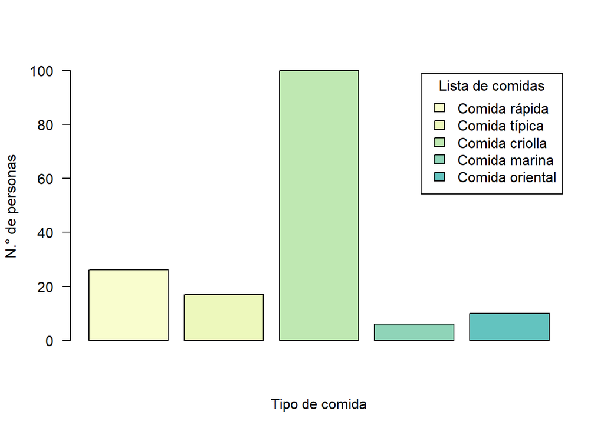

```
El tipo de comida que más eligen los estudiantes de UTEC al momento de salir a comer es la Comida Criolla, muy por encima de los otros.
```

```r
    barplot((cantidad), xlab='Tipo de comida',
            ylab='N.° de personas', las=1, col=c("#F9FDCE","#EDF8BC","#BFE8B2","#8FD4B8","#63C3BF"), las=1)
    legend(x = "topright", legend = c("Comida rápida","Comida típica","Comida criolla","Comida marina","Comida oriental"), fill=c("#F9FDCE","#EDF8BC","#BFE8B2","#8FD4B8","#63C3BF"), cex=1, horiz= FALSE, inset = 0.0099, title=("Lista de comidas"))
```

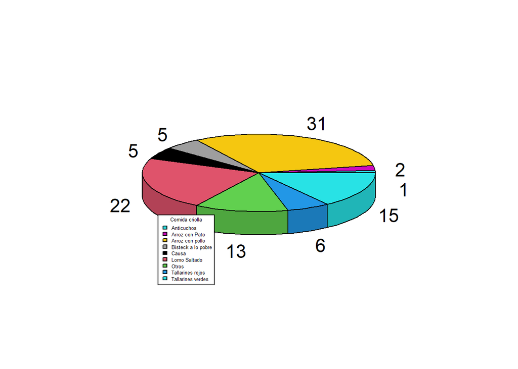

```
Podemos apreciar que dentro de la categoría `Comida Criolla` la más solicitada es `Arroz con Pollo`. En este caso la predominancia del más popular no es tanto como en el tipo de comida. Por ejemplo, se puede ver que el Lomo Saltado también goza de una gran preferencia.
```

```r
    pie3D(pancho,labels=pancho, col=5:14, labelcol="black", border="black")
    legend("bottomleft", legend = c("Anticuchos", "Arroz con Pato", "Arroz con pollo","Bisteck a lo pobre","Causa","Lomo Saltado","Otros","Tallarines rojos","Tallarines verdes"), fill =  5:14, cex=0.4, inset = 0.099999999999999999999, title=("Comida criolla"))
```

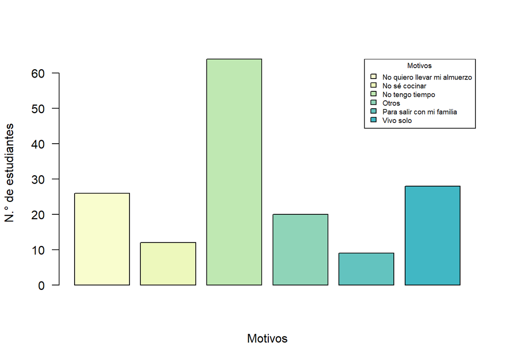

```
Visualmente, podemos determinar que el principal motivo por el cuál los estudiantes de UTEC almuerzan en la calle es debido a que `No tienen tiempo`.
```

```r
    barplot(mati, xlab='Motivos',col=c("#F9FDCE","#EDF8BC","#BFE8B2","#8FD4B8","#63C3BF","#41B7C4"),ylab='N.° de estudiantes', las=1)
    legend(x = "topright", legend = c("No quiero llevar mi almuerzo","No sé cocinar","No tengo tiempo","Otros", "Para salir con mi familia","Vivo solo"),fill=c("#F9FDCE","#EDF8BC","#BFE8B2","#8FD4B8","#63C3BF","#41B7C4"),cex=0.6,title=("Motivos"))
```

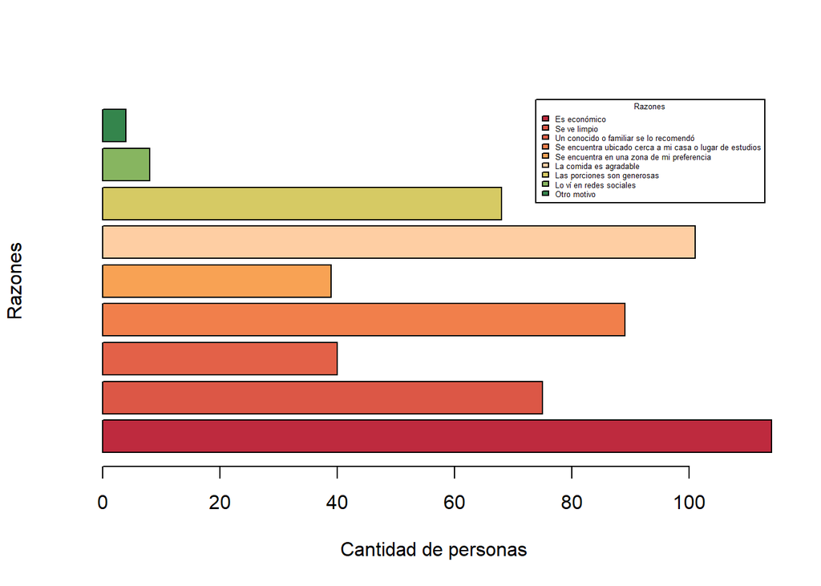

```
Como podemos apreciar, la razón por la cuál los estudiantes de UTEC eligen un restaurante a la hora de almorzar es porque `Es económico`, siguiéndole `La comida es agradable`.

Cuando hemos realizado nuestra encuesta, solicitamos a los estudiantes que nos comentaran si es que pedían entrada, postre y tipo de bebida, esto fue lo que obtuvimos:
```

```r
    barplot((vector), xlab='Cantidad de personas',
            ylab='Razones', las=1, col=c("#BE2A3E","#DC5746","#E36148","#F17F4B","#F8A254","#FECEA3","#D6CA64","#87B560","#34854C"), horiz= TRUE, las=1)
    legend(x = "topright", legend = c("Es económico","Se ve limpio","Un conocido o familiar se lo recomendó","Se encuentra ubicado cerca a mi casa o lugar de estudios","Se encuentra en una zona de mi preferencia","La comida es agradable","Las porciones son generosas","Lo ví en redes sociales","Otro motivo"), fill=c("#BE2A3E","#DC5746","#E36148","#F17F4B","#F8A254","#FECEA3","#D6CA64","#87B560","#34854C"), cex=0.4, horiz= FALSE, inset = 0.0099, title=("Razones"))
```

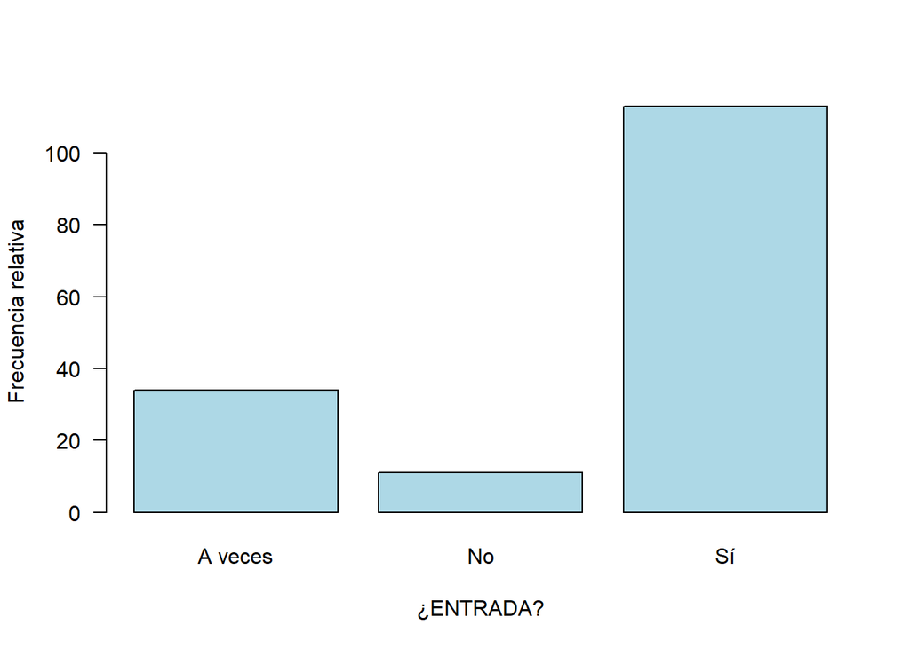

```r
barplot(table(DF$Entrada), col = "lightblue", xlab='¿ENTRADA?',
        ylab='Frecuencia relativa', las=1)
```

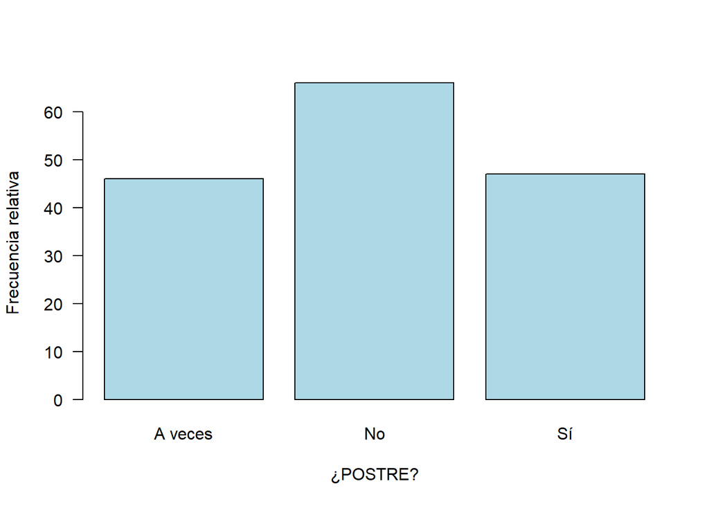

```r
barplot(table(DF$Postre), col = "lightblue", xlab='¿POSTRE?',
        ylab='Frecuencia relativa', las=1)
```

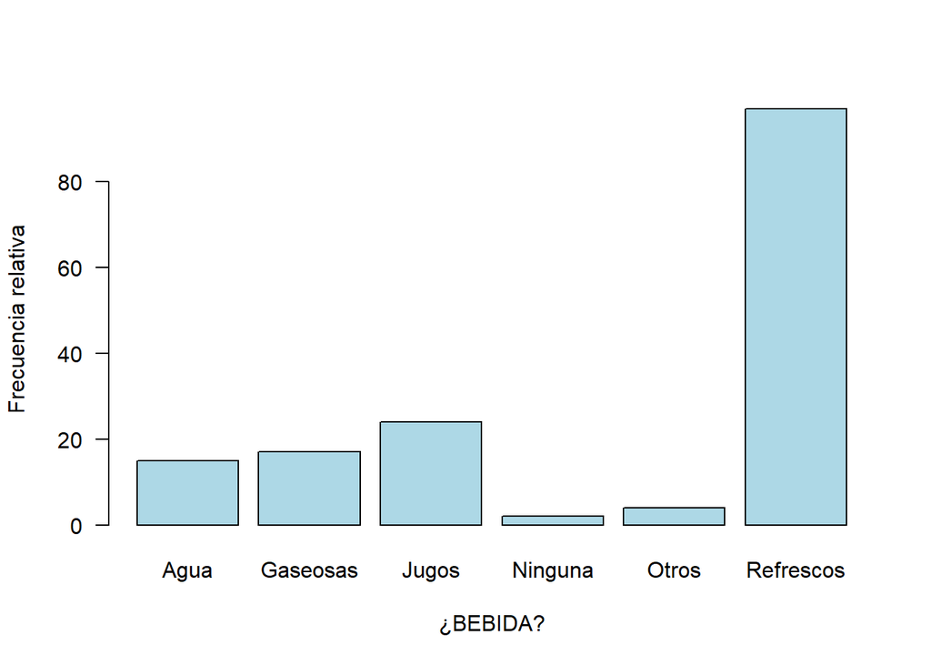

[output not shown]

```r
barplot(table(DF$Bebida), col = "lightblue", xlab='¿BEBIDA?',
        ylab='Frecuencia relativa', las=1)
```

### Conclusiones:

```
El tipo de comida preferido por los estudiantes es la comida criolla, con el arroz con pollo como platillo con mayor preferencia.
Los estudiantes en general no prefieren postre, gustan de entrada y en casi todos los casos acompañan sus almuerzos con una bebida.
```

## **OBJETIVO 2:**

### Conocer la cantidad necesaria de tiempo que los individuos requieren para consumir sus alimentos.

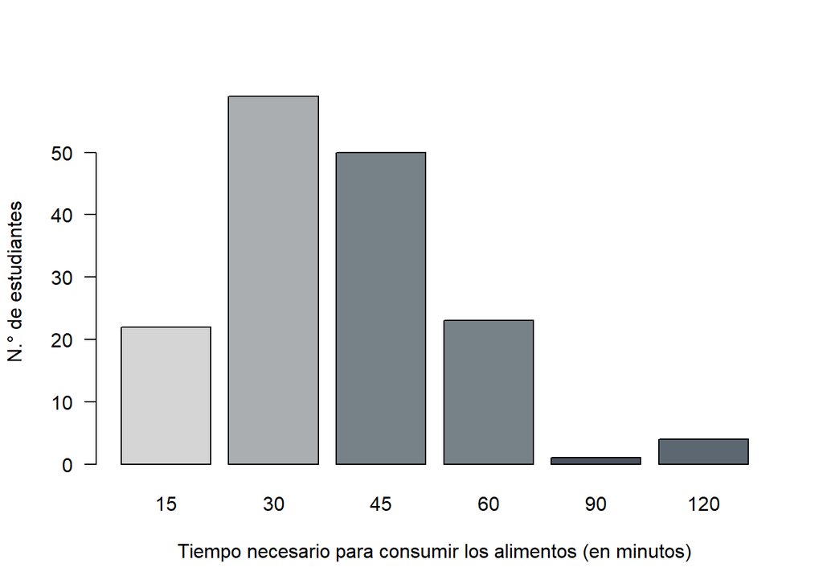

```
Con los datos obtenidos, podemos apreciar que los estudiantes comen mayormente en 30 minutos.
Si analizamos a qué se debe esto, habrían diversas suposiciones.
```

```r
barplot(table(DF$Tiempo), xlab='Tiempo necesario para consumir los alimentos (en minutos)', ylab='N.° de estudiantes', las=1,col=c("#D5D5D5","#AAAEB0","#768188","#768188","#49525E","#5D6772","#4D5662"))
```

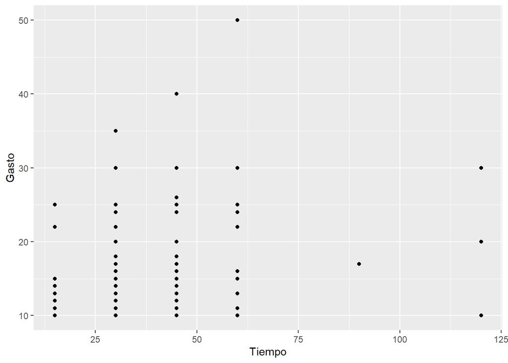

```
La mayoría de estudiantes que almuerzan en 15 minutos gastan 15 soles o menos. Posiblemente al tener poco tiempo para comer prefieren no invertir mucho en un almuerzo
```

```r
ggplot(aes(x=Tiempo,y=Gasto),data=DF)+
  geom_point()
```

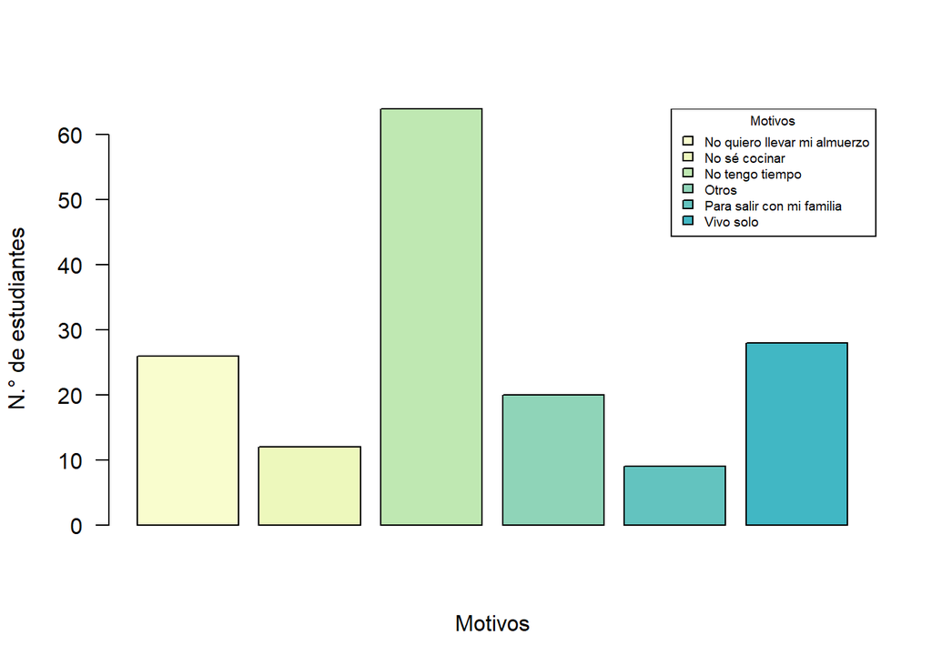

[output not shown]

```r
    barplot(mati, xlab='Motivos',col=c("#F9FDCE","#EDF8BC","#BFE8B2","#8FD4B8","#63C3BF","#41B7C4"),ylab='N.° de estudiantes', las=1)
    legend(x = "topright", legend = c("No quiero llevar mi almuerzo","No sé cocinar","No tengo tiempo","Otros", "Para salir con mi familia","Vivo solo"),fill=c("#F9FDCE","#EDF8BC","#BFE8B2","#8FD4B8","#63C3BF","#41B7C4"),cex=0.6,title=("Motivos"))
```

### Sesgo de la variable tiempo:

```r
summary(DF$Tiempo)
```

```
##    Min. 1st Qu.  Median    Mean 3rd Qu.    Max.
##   15.00   30.00   30.00   39.62   45.00  120.00
```

```r
Tiempito<-DF$Tiempo
medianaT<-median(Tiempito)
media<-mean(Tiempito, na.rm=T)
desviacionE<-sd(Tiempito, na.rm=T)
```

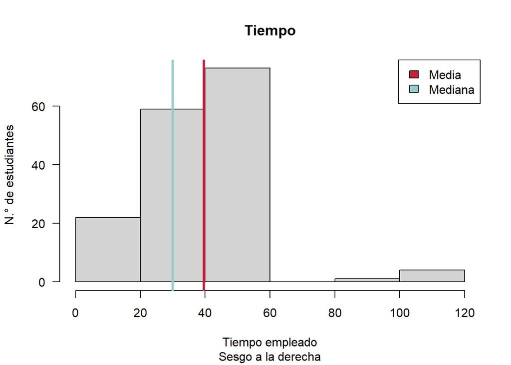

```r
#### Sesgo de nuestra variable Tiempo
hist(Tiempito,breaks=5,las=1, main = "Tiempo", xlab= "Tiempo empleado", ylab="N.° de estudiantes", sub="Sesgo a la derecha")
abline(v=media,col="#C71F3C",lwd=3)
abline(v=medianaT,col="#92CCCE",lwd=3)
legend(x="topright", legend=c("Media", "Mediana"), fill=c("#C71F3C","#92CCCE"))
```

Verificamos con la gráfica de sesgo que el comportamiento que tenemos no es normal y tiene un sesgo a la derecha.

### Conclusiones:

```
La mayoría de los estudiantes almuerzan en 30 min, un tiempo no exagerado. Esto es posiblemente debido a que la razón más frecuente de almorzar en la calle es no tener tiempo para cocinar.
```

## **OBJETIVO 3:**

### Determinar las razones de los métodos de pago preferidos y la cantidad de dinero que gastan los estudiantes UTEC

```
Para poder determinar las razones de uso de los métodos de pago preferidos y la cantidad de dinero que gastan los estudiantes UTEC, analizaremos las variables Edad, Costo, Medio de pago y Razones por las que eligen un restaurante.
```

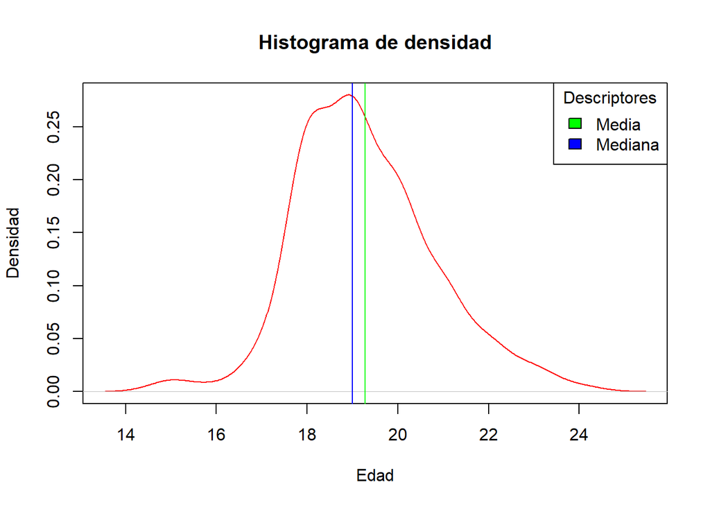

```
Se puede apreciar que la edad promedio es de 19 años, esto indicaría que muchos estudiantes recién habrían cumplido la mayoría de edad y algunos incluso no.
```

```r
prom_ed <- mean(DF$Edad, na.rm=TRUE)
median_ed <- median(DF$Edad, na.rm=TRUE)

densidad_ciclo <- density(DF$Edad)
plot(densidad_ciclo,
     main = "Histograma de densidad",
     xlab = "Edad",
     ylab = "Densidad",
     col = "red")

abline(v = c(prom_ed, median_ed), col = c("green", "blue"))
legend(x = "topright",
       legend = c("Media", "Mediana"),
       fill = c("green", "blue"),
       title = "Descriptores")
```

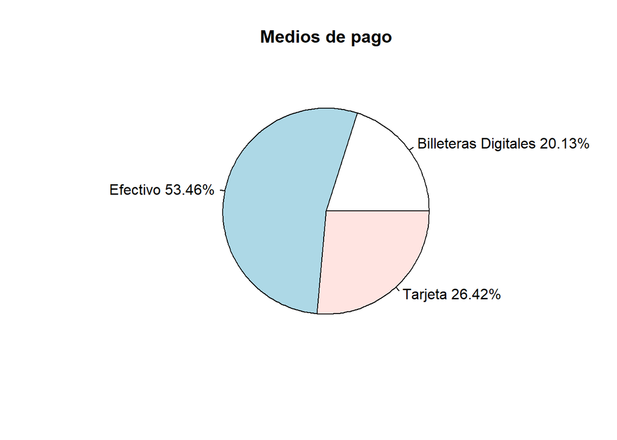

[output not shown]

```r
pie(porcentajes, etiquetas,
    main = "Medios de pago")
```

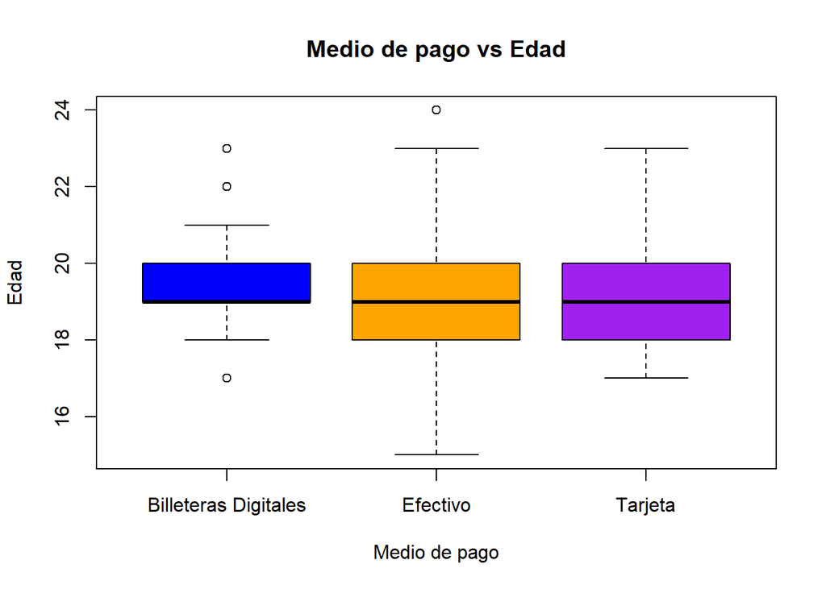

[output not shown]

```r
boxplot(DF$Edad~ DF$MPago, main= "Medio de pago vs Edad", xlab= "Medio de pago", ylab = "Edad", col= c("blue","orange","purple"))
```

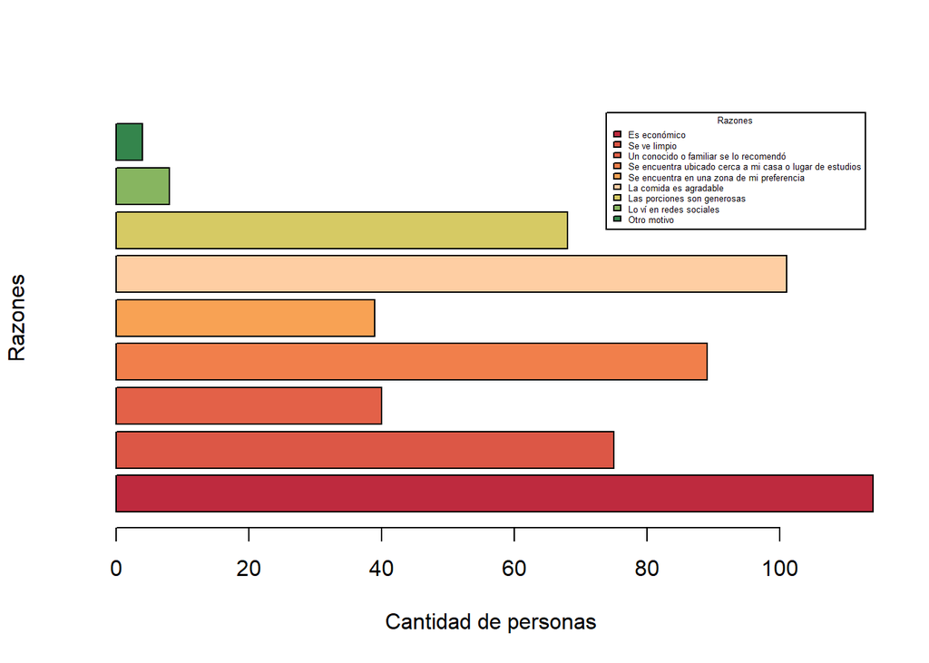

```
La razón principal por la que los estudiantes escogen un restaurante es porque la comida es económica.
Esto podría demostrar que los estudiantes tienen como prioridad gastar la menor cantidad de dinero.
```

```r
    barplot((vector), xlab='Cantidad de personas',
            ylab='Razones', las=1, col=c("#BE2A3E","#DC5746","#E36148","#F17F4B","#F8A254","#FECEA3","#D6CA64","#87B560","#34854C"), horiz= TRUE, las=1)
    legend(x = "topright", legend = c("Es económico","Se ve limpio","Un conocido o familiar se lo recomendó","Se encuentra ubicado cerca a mi casa o lugar de estudios","Se encuentra en una zona de mi preferencia","La comida es agradable","Las porciones son generosas","Lo ví en redes sociales","Otro motivo"), fill=c("#BE2A3E","#DC5746","#E36148","#F17F4B","#F8A254","#FECEA3","#D6CA64","#87B560","#34854C"), cex=0.4, horiz= FALSE, inset = 0.0099, title=("Razones"))
```

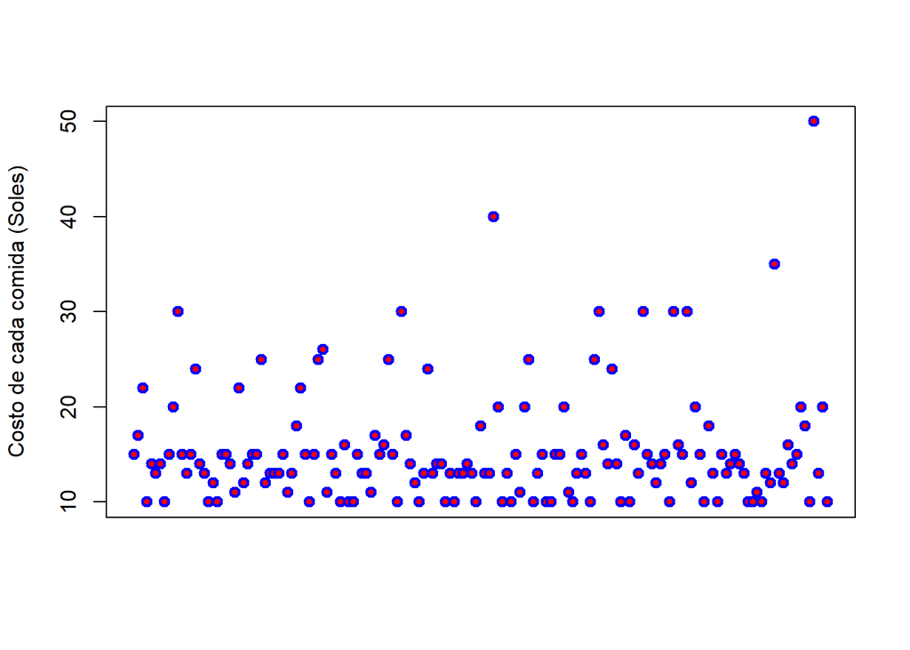

```r
plot(DF$Gasto, xaxt = "n", xlab="", ylab = "Costo de cada comida (Soles)", pch = 21, bg = "red", col = "blue", cex = 1, lwd = 2)
```

```r
100*sd(DF$Gasto,  na.rm = TRUE)/mean(DF$Gasto,  na.rm = TRUE)
```

```
## [1] 39.62096
```

```
La cantidad que los estudiantes pagan es muy diversa ya que la variabilidad entre las variables es de un 39%.
Sin embargo, se aprecia que la mayoría de estudiantes paga menos de 20 soles y esto estaría acorde a que el medio de pago sea el efectivo, ya que esa es una cantidad de dinero fácilmente portable.
```

```r
mlv(DF$Gasto, method = "mfv")
```

```
## [1] 10
```

```
Finalmente, usando una función para hallar la moda, tenemos que el valor más popular de gasto en un almuerzo es el de 10 soles.
```

### Conclusiones:

```
El medio de pago más popular es el efectivo, esto podría ser posible debido a que varios estudiantes no tienen tarjeta ni billeteras digitales.
Los estudiantes prefieren ahorrar al momento de comprar sus comidas, pagando la mayoría 20 soles o menos.
```